# BigAss bird phylogeography data exploration

Here are some maps exploring our bird data. I have two sets of maps: Maps only with cells where there are at least three individuals per species (>= 3 species tab), and maps that show the species density, rather than observation density (Species density tab).

First I’m reading in the packages and reading in the data.

```r
packages <- c("magrittr", "tidyverse", "sf", "leaflet", "maps", "ggmap", "viridis", "raster", "maptools", "data.table")
lapply(packages, require, character.only = TRUE)
#read in data
bird_data <- read.csv("sample_key_68_clean.csv")
```

I’m removing all of the irrelevant columns for mapping, I’m only keeping ingroup individuals, and I’m removing all localities that aren’t in South America.

```r
#remove irrelevant columns, NAs, North American/European localities,and subset for ingroup individuals. orig # obs = 18954; filtered # obs = 2825
bird_data <- subset(bird_data, select = c("Sample.Name","Country", "State", "Locality", "Genus", "Species", "Ingroup", "Lat", "Long")) %>%
  subset(Ingroup == "y") %>%
  subset(Lat < 12.5) %>%
  subset(!(Country %in% c("Mexico", "Cuba", "Bahamas", "Dominican Republic", "Nicaragua", "Costa Rica", "Panama"))) %>%
  na.omit() %>%
  drop.levels()
```

The original number of observations was 18954, and the filtered number of observations is 2825.

Now time for the map! This is of all of our South American localities colored according to country to find outlier/mislabeled points.

```r
#convert locality data to a spatial object. The spatial object is basically a shape file that the mapping function can interpret.
coord_points <- st_as_sf(bird_data, coords = c("Long", "Lat"),
                         crs = 4326, agr = "constant")
#load a world map as the base map.
w_map <- map("world", plot = FALSE)
#make color palette
pal <- colorFactor(palette = "inferno", domain = NULL, na.color = "#00000000")
#create popup labels for points
popup_label <- paste(coord_points$Genus, coord_points$Species, "<br>",
                     coord_points$Country, "<br>",
                     coord_points$Locality, "<br>",
                     coord_points$geometry)
#plot in leafly
leaflet(data = w_map) %>%
  addTiles() %>%
  addCircleMarkers(data = coord_points,
                  color = ~pal(Country),
                  radius = 5,
                  popup = popup_label)
```

[interactive chart not shown]

Now I’m going to apply various filters to the data to look at sampling intensity.

## Sampling Maps

### >=3 per species

Here I’m subsetting the data for only those cells where there are more than 3 observations for a species and then plotting.

100x100 km. Dataset is reduced from 68 to 49 species and from 2825 observations to 1700 observations.

```r
#plot count map
leaflet(data = sa_clim_1d) %>%
  addTiles() %>%
  addRasterImage(count_pts_1d, colors = pal.numseq,  opacity = 0.8) %>%
  addLegend(pal = pal.numseq, values = values(count_pts_1d))
```

[output not shown]

200x200 km. 68 to 49 species and 2825 to 1955 observations

```r
#plot count map
leaflet(data = sa_clim_2d) %>%
  addTiles() %>%
  addRasterImage(count_pts_2d, colors = pal.numseq.two,  opacity = 0.8) %>%
  addLegend(pal = pal.numseq.two, values = values(count_pts_2d))
```

```
no non-missing arguments to min; returning Infno non-missing arguments to max; returning -Inf
```

[interactive chart not shown]

300x300 km. 68 to 54 species and 2825 to 2149 observations

```r
#plot count map
leaflet(data = sa_clim_3d) %>%
  addTiles() %>%
  addRasterImage(count_pts_3d, colors = pal.numseq.three,  opacity = 0.8) %>%
  addLegend(pal = pal.numseq.three, values = values(count_pts_3d))
```

```
no non-missing arguments to min; returning Infno non-missing arguments to max; returning -Inf
```

[interactive chart not shown]

### Species density

Now I’m going to look at species density per cell for the three resolutions! Just to be clear, this is still using the data set filtered for >= 3 observations per species per cell.

100 km.

```r
#plot count map
leaflet(data = sa_clim_1d) %>%
  addTiles() %>%
  addRasterImage(count_pts_1d_sp, colors = pal2,  opacity = 0.8) %>%
  addLegend(pal = pal2, values = values(count_pts_1d_sp))
```

```
108 projected point(s) not finite108 projected point(s) not finiteno non-missing arguments to min; returning Infno non-missing arguments to max; returning -Inf108 projected point(s) not finite
```

[interactive chart not shown]

200 km.

```r
pts_ext_2d_sp <- as.data.frame(pts_ext_2d) #convert to data frame for filtering
pts_ext_2d_sp <- pts_ext_2d_sp[!duplicated(pts_ext_2d_sp[c("Species", "cells")]),] #filter for unique species in each cell
coordinates(pts_ext_2d_sp) <- ~Long+Lat #convert to a spatial data frame
count_pts_2d_sp <- rasterize(pts_ext_2d_sp, sa_clim_2d, fun = "count", field = "Species") #make a raster out of the counts of observations per cell
#plot count map
leaflet(data = sa_clim_2d) %>%
  addTiles() %>%
  addRasterImage(count_pts_2d_sp, colors = pal2,  opacity = 0.8) %>%
  addLegend(pal = pal2, values = values(count_pts_2d_sp))
```

```
no non-missing arguments to min; returning Infno non-missing arguments to max; returning -Inf
```

[interactive chart not shown]

300 km.

```r
pts_ext_3d_sp <- as.data.frame(pts_ext_3d) #convert to data frame for filtering
pts_ext_3d_sp <- pts_ext_3d_sp[!duplicated(pts_ext_3d_sp[c("Species", "cells")]),] #filter for unique species in each cell
coordinates(pts_ext_3d_sp) <- ~Long+Lat #convert to a spatial data frame
count_pts_3d_sp <- rasterize(pts_ext_3d_sp, sa_clim_3d, fun = "count", field = "Species") #make a raster out of the counts of observations per cell
#plot count map
leaflet(data = sa_clim_3d) %>%
  addTiles() %>%
  addRasterImage(count_pts_3d_sp, colors = pal2,  opacity = 0.8) %>%
  addLegend(pal = pal2, values = values(count_pts_3d_sp))
```

```
no non-missing arguments to min; returning Infno non-missing arguments to max; returning -Inf
```

[interactive chart not shown]

### Genetic Diversity

Here, I’m extracting the nexus files for each species in each grid cell (i.e. the same species may have multiple nexus files if it’s in multiple grid cells) and calculating pi from them.

Here’s some housekeeping before applying to each spatial filtering level.

```r
for (file in 1:length(seq.files)){
  print(seq.files[file]) #print when first running on a data sets so you can tell which file is corrupt if an error occurs. Probably more reasonable to add an if/then statement, but whatever
  sp.nex <- read.nexus.data(paste("../S1_Data/", seq.files[file], sep = ""))
  all.seq <- append(all.seq, sp.nex)
}
```

[output not shown]

[output cut: 163 more lines]

100x100 km resolution. Values are mean pi per raster cell.

```r
#split data frame by cell number and species, creating nexus files for each species per cell
species.seq.split.one <- pts_ext_1d %>%
  as.data.frame() %>% #some functions don't like spatial data frames
  drop.levels() %>%
  split(.$cells) %>% #split into a list of data frames, grouped by cell. Splitting by both cells and species at once doesn't work.
  lapply(drop.levels) %>% #drop any levels in the data frame. Have to perform first because extra factor levels can mess up the split function
  lapply(function(x){
  split(x, x$Species)}) %>% #split each cell by species
  drop.levels()
#write a nexus file for each group of sequences from a cell.
dir.create("../bird-seqs-one")
```

```
'../bird-seqs-one' already exists
```

```r
for (i in 1:length(species.seq.split.one)) {
  df <- species.seq.split.one[[i]]
  for (j in 1:length(df)){
    samples <- df[[j]]$Sample.Name#make a vector of sample names from each data set
    seqs <- all.seq[samples] #subset all.seq for the samples
    #seqs2 <- Filter(Negate(is.null), seqs) #remove any null results (i.e. remove if a sample name from the spreadsheet doesn't match with a sample from the nexus)
    if(length(seqs) < 3) next #don't write to a nexus file if there are less than 3 sequences
    write.nexus.data(seqs, file = paste0("../bird-seqs-one/", names(species.seq.split.one)[[i]], ".", names(df)[[j]], ".nex"), interleaved = FALSE) #write to a nexus file, which is named by the cell number
  }
}
#get a list of the nexus files
files <- paste0("../bird-seqs-one/", list.files("../bird-seqs-one"))
pi.total.one <- files %>% sapply(pi.calc.fun) #calculate pi for all each species within each cell
num.seq.one <- files %>% sapply(num.seq.fun)
pi.names.one <- str_match_all(names(pi.total.one), "[0-9]+") %>% unlist() #make a vector of the cell numbers for each pi calculation
pi.df.one <- bind_cols(cells = pi.names.one, pi = unname(pi.total.one), numseq = unname(num.seq.one)) #create dataframe of pi calculations
pi.means.one <- pi.df.one %>% group_by(cells) %>% dplyr::summarise(mean.pi = mean(pi), sd.pi = sd(pi), numseq = sum(numseq)) #calculate pi for each cell number. I'm using dplyr::summarise because plyr also has a summarise function that can create a lot of confusion.
pts.ext.one.pi <- merge(pts_ext_1d, pi.means.one, by = "cells") #make new spatial data frame including the pi values
pi.raster.one <- rasterize(pts.ext.one.pi, sa_clim_1d, fun = "first", field = "mean.pi") #create new raster of mean pi values per cell
leaflet() %>%
  addTiles() %>%
  addRasterImage(pi.raster.one, colors = pal.one,  opacity = 0.8) %>%
  addLegend(pal = pal.one, values = values(pi.raster.one))
```

```
no non-missing arguments to min; returning Infno non-missing arguments to max; returning -Inf
```

[interactive chart not shown]

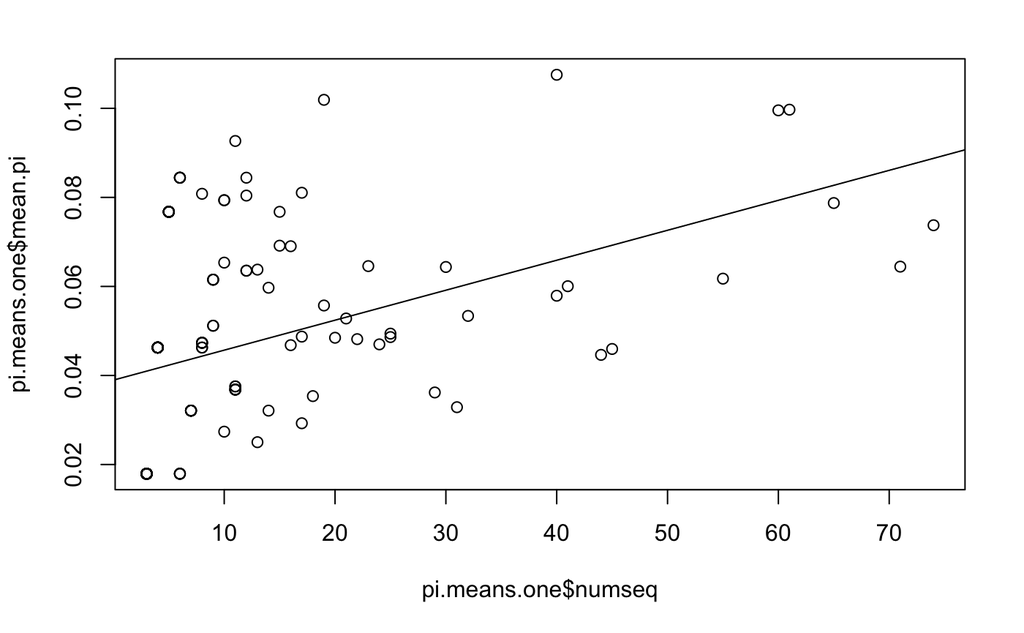

```r
#plot the mean pi value as a function of the number of sequences to see if the number of sequences influence the calculation of genetic diversity. It appears to.
plot(pi.means.one$mean.pi ~ pi.means.one$numseq)
model <- lm(mean.pi ~ numseq, data = pi.means.one)
abline(model)
```

200x200 km

```r
#split data frame by cell number and species, creating nexus files for each species per cell
species.seq.split.two <- pts_ext_2d %>%
  as.data.frame() %>% #some functions don't like spatial data frames
  drop.levels() %>%
  split(.$cells) %>% #split into a list of data frames, grouped by cell. Splitting by both cells and species at once doesn't work.
  lapply(drop.levels) %>% #drop any levels in the data frame. Have to perform first because extra factor levels can mess up the split function
  lapply(function(x){
  split(x, x$Species)}) %>% #split each cell by species
  drop.levels()
#write a nexus file for each group of sequences from a cell.
dir.create("../bird-seqs-two")
```

```
'../bird-seqs-two' already exists
```

```r
for (i in 1:length(species.seq.split.two)) {
  df <- species.seq.split.two[[i]]
  for (j in 1:length(df)){
    samples <- df[[j]]$Sample.Name #make a vector of sample names from each data set
    seqs <- all.seq[samples] #subset all.seq for the samples
    #seqs2 <- Filter(Negate(is.null), seqs) #remove any null results (i.e. remove if a sample name from the spreadsheet doesn't match with a sample from the nexus)
    if(length(seqs) < 3) next #don't write to a nexus file if there are less than 3 sequences
    write.nexus.data(seqs, file = paste0("../bird-seqs-two/", names(species.seq.split.two)[[i]], ".", names(df)[[j]], ".nex"), interleaved = FALSE) #write to a nexus file, which is named by the cell number
  }
}
#get a list of the nexus files
files <- paste0("../bird-seqs-two/", list.files("../bird-seqs-two"))
pi.total.two <- files %>% sapply(pi.calc.fun) #calculate pi for all each species within each cell
num.seq.two <- files %>% sapply(num.seq.fun)
pi.names.two <- str_match_all(names(pi.total.two), "[0-9]+") %>% unlist() #make a vector of the cell numbers for each pi calculation
pi.df.two <- bind_cols(cells = pi.names.two, pi = unname(pi.total.two), numseq = unname(num.seq.two)) #create dataframe of pi calculations
pi.means.two <- pi.df.two %>% group_by(cells) %>% dplyr::summarise(mean.pi = mean(pi), sd.pi = sd(pi), numseq = sum(numseq)) #calculate pi for each cell number. I'm using dplyr::summarise because plyr also has a summarise function that can create a lot of confusion.
pts.ext.two.pi <- merge(pts_ext_2d, pi.means.two, by = "cells") #make new spatial data frame including the pi values
pi.raster.two <- rasterize(pts.ext.two.pi, sa_clim_2d, fun = "first", field = "mean.pi") #create new raster of mean pi values per cell
leaflet() %>%
  addTiles() %>%
  addRasterImage(pi.raster.two, colors = pal.one,  opacity = 0.8) %>%
  addLegend(pal = pal.one, values = values(pi.raster.two))
```

```
no non-missing arguments to min; returning Infno non-missing arguments to max; returning -Inf
```

[interactive chart not shown]

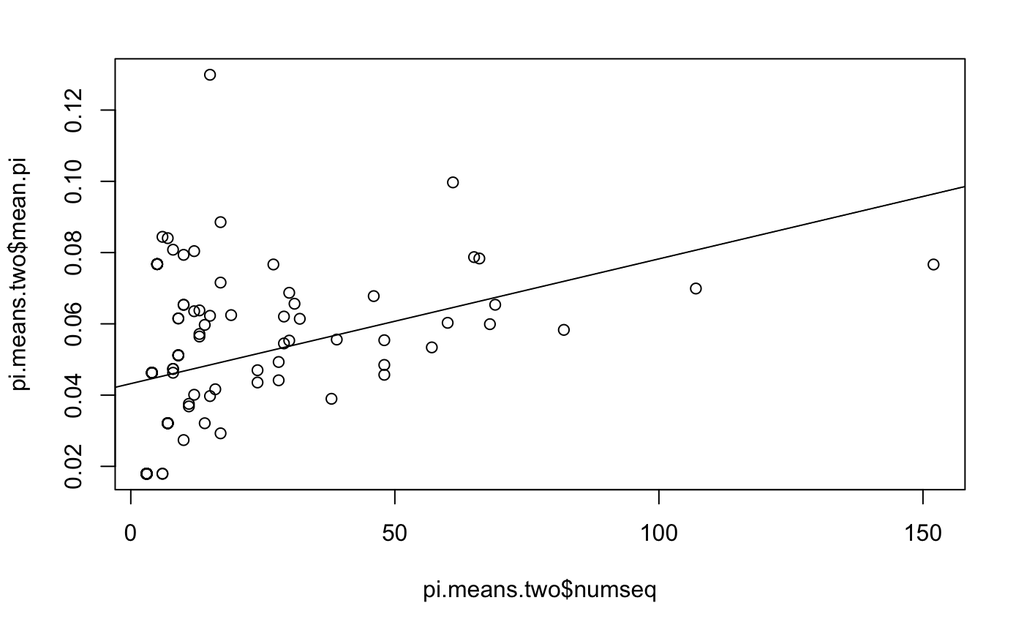

```r
plot(pi.means.two$mean.pi ~ pi.means.two$numseq)
model <- lm(mean.pi ~ numseq, data = pi.means.two)
abline(model)
```

300x300 km

```r
#split data frame by cell number and species, creating nexus files for each species per cell
species.seq.split.three <- pts_ext_3d %>%
  as.data.frame() %>% #some functions don't like spatial data frames
  drop.levels() %>%
  split(.$cells) %>% #split into a list of data frames, grouped by cell. Splitting by both cells and species at once doesn't work.
  lapply(drop.levels) %>% #drop any levels in the data frame. Have to perform first because extra factor levels can mess up the split function
  lapply(function(x){
  split(x, x$Species)}) %>% #split each cell by species
  drop.levels()
#write a nexus file for each group of sequences from a cell.
dir.create("../bird-seqs-three")
```

```
'../bird-seqs-three' already exists
```

```r
for (i in 1:length(species.seq.split.three)) {
  df <- species.seq.split.three[[i]]
  for (j in 1:length(df)){
    samples <- df[[j]]$Sample.Name #make a vector of sample names from each data set
    seqs <- all.seq[samples] #subset all.seq for the samples
    #seqs2 <- Filter(Negate(is.null), seqs) #remove any null results (i.e. remove if a sample name from the spreadsheet doesn't match with a sample from the nexus)
    if(length(seqs) < 3) next #don't write to a nexus file if there are less than 3 sequences
    write.nexus.data(seqs, file = paste0("../bird-seqs-three/", names(species.seq.split.three)[[i]], ".", names(df)[[j]], ".nex"), interleaved = FALSE) #write to a nexus file, which is named by the cell number
  }
}
#get a list of the nexus files
files <- paste0("../bird-seqs-three/", list.files("../bird-seqs-three"))
pi.total.three <- files %>% sapply(pi.calc.fun) #calculate pi for all each species within each cell
num.seq.three <- files %>% sapply(num.seq.fun)
pi.names.three <- str_match_all(names(pi.total.three), "[0-9]+") %>% unlist() #make a vector of the cell numbers for each pi calculation
pi.df.three <- bind_cols(cells = pi.names.three, pi = unname(pi.total.three), numseq = unname(num.seq.three)) #create dataframe of pi calculations
pi.means.three <- pi.df.three %>% group_by(cells) %>% dplyr::summarise(mean.pi = mean(pi), sd.pi = sd(pi), numseq = sum(numseq)) #calculate pi for each cell number. I'm using dplyr::summarise because plyr also has a summarise function that can create a lot of confusion.
pts.ext.three.pi <- merge(pts_ext_3d, pi.means.three, by = "cells") #make new spatial data frame including the pi values
pi.raster.three <- rasterize(pts.ext.three.pi, sa_clim_3d, fun = "first", field = "mean.pi") #create new raster of mean pi values per cell
leaflet() %>%
  addTiles() %>%
  addRasterImage(pi.raster.three, colors = pal.one,  opacity = 0.8) %>%
  addLegend(pal = pal.one, values = values(pi.raster.three))
```

```
no non-missing arguments to min; returning Infno non-missing arguments to max; returning -Inf
```

[interactive chart not shown]

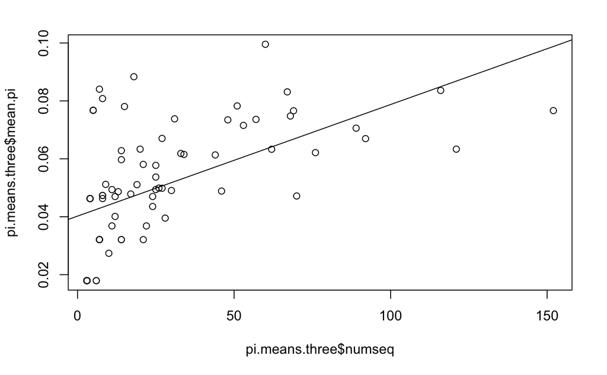

```r
#plot the mean pi value as a function of the number of sequences to see if the number of sequences influence the calculation of genetic diversity. It appears to.
plot(pi.means.three$mean.pi ~ pi.means.three$numseq)
model <- lm(mean.pi ~ numseq, data = pi.means.three)
abline(model)
```

### Genetic Diversity Error

100x100 km

```r
pi.raster.sd.one <- rasterize(pts.ext.one.pi, sa_clim_1d, fun = "first", field = "sd.pi") #create new raster of mean pi values per cell
leaflet() %>%
  addTiles() %>%
  addRasterImage(pi.raster.sd.one, colors = pal.one,  opacity = 0.8) %>%
  addLegend(pal = pal.one, values = values(pi.raster.sd.one))
```

```
no non-missing arguments to min; returning Infno non-missing arguments to max; returning -Inf
```

[interactive chart not shown]

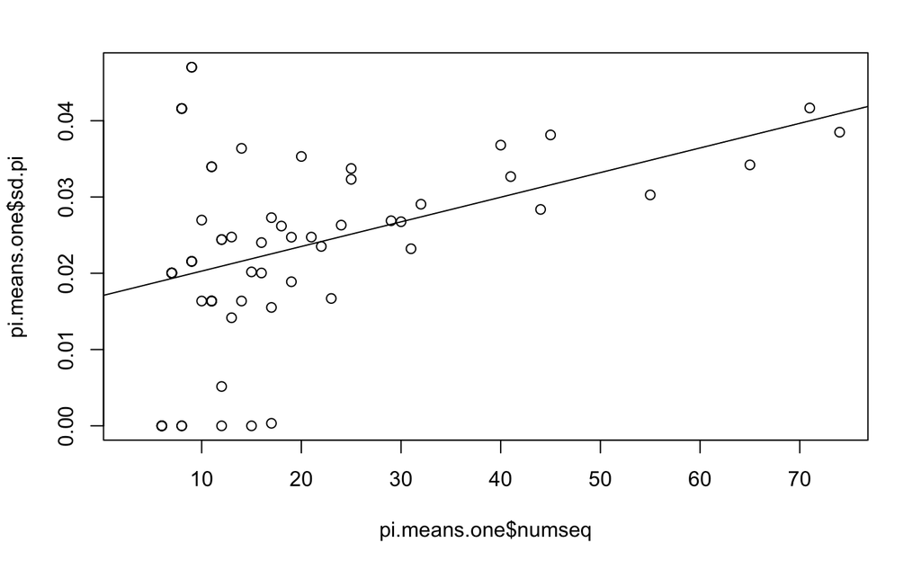

```r
#plot the mean pi value as a function of the number of sequences to see if the number of sequences influence the calculation of genetic diversity. It appears to.
plot(pi.means.one$sd.pi ~ pi.means.one$numseq)
model <- lm(sd.pi ~ numseq, data = pi.means.one)
abline(model)
```

200x200 km

```r
pi.raster.sd.two <- rasterize(pts.ext.two.pi, sa_clim_2d, fun = "first", field = "sd.pi") #create new raster of mean pi values per cell
leaflet() %>%
  addTiles() %>%
  addRasterImage(pi.raster.sd.two, colors = pal.one,  opacity = 0.8) %>%
  addLegend(pal = pal.one, values = values(pi.raster.sd.two))
```

```
no non-missing arguments to min; returning Infno non-missing arguments to max; returning -Inf
```

[interactive chart not shown]

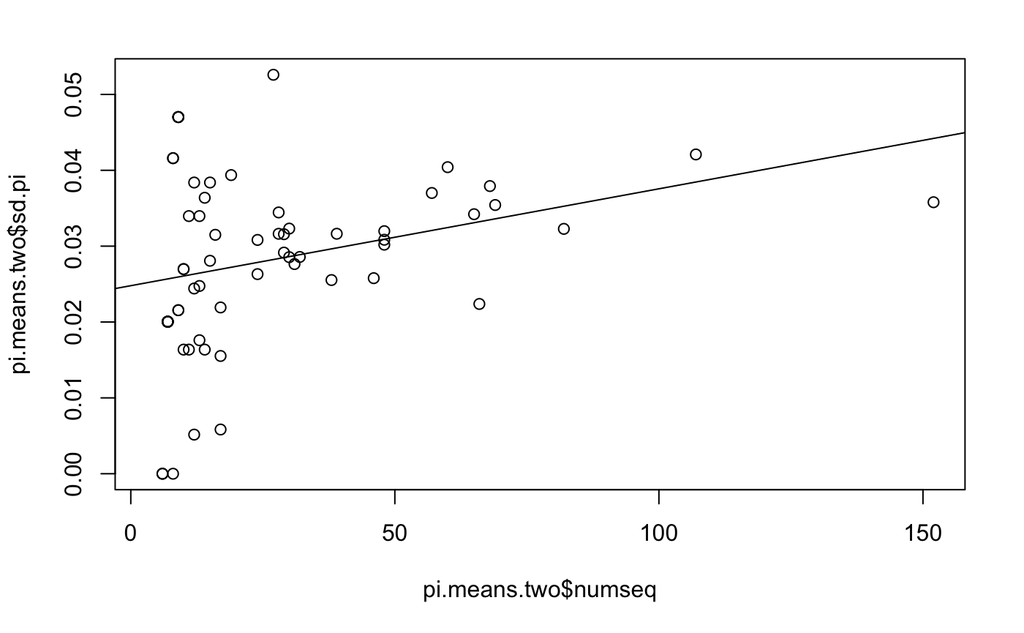

```r
#plot the mean pi value as a function of the number of sequences to see if the number of sequences influence the calculation of genetic diversity. It appears to.
plot(pi.means.two$sd.pi ~ pi.means.two$numseq)
model <- lm(sd.pi ~ numseq, data = pi.means.two)
abline(model)
```

300x300 km

```r
pi.raster.sd.three <- rasterize(pts.ext.three.pi, sa_clim_3d, fun = "first", field = "sd.pi") #create new raster of mean pi values per cell
leaflet() %>%
  addTiles() %>%
  addRasterImage(pi.raster.sd.three, colors = pal.one,  opacity = 0.8) %>%
  addLegend(pal = pal.one, values = values(pi.raster.sd.three))
```

```
no non-missing arguments to min; returning Infno non-missing arguments to max; returning -Inf
```

[interactive chart not shown]

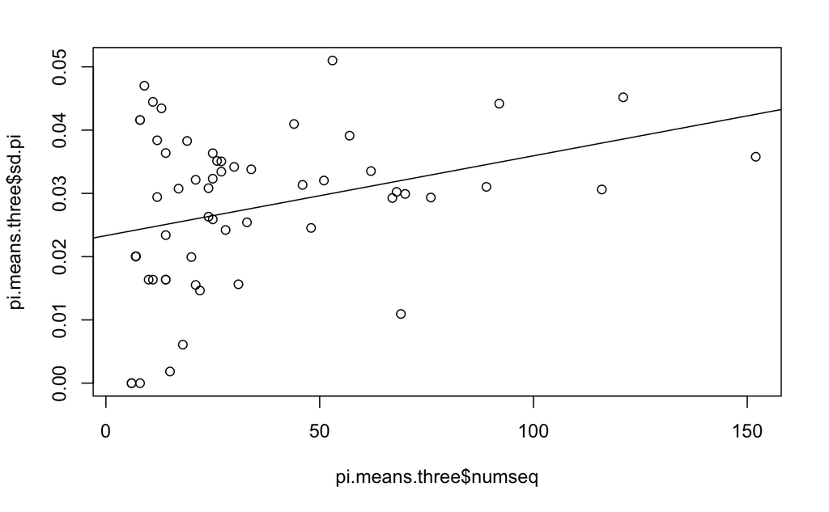

```r
#plot the mean pi value as a function of the number of sequences to see if the number of sequences influence the calculation of genetic diversity. It appears to.
plot(pi.means.three$sd.pi ~ pi.means.three$numseq)
model <- lm(sd.pi ~ numseq, data = pi.means.three)
abline(model)
```

### Num Sequences

This is just a sanity check to make sure there weren’t any major differences in the number of sequences extracted and the number of sequences listed in the spreadsheet. These should look similar to the plots in the “>3 per species” tab.

100 x 100 km

```r
leaflet() %>%
  addTiles() %>%
  addRasterImage(pi.raster.numseq.one, colors = pal.numseq,  opacity = 0.8) %>%
  addLegend(pal = pal.numseq, values = values(pi.raster.numseq.one))
```

```
no non-missing arguments to min; returning Infno non-missing arguments to max; returning -Inf
```

[interactive chart not shown]

200 x 200 km

```r
leaflet() %>%
  addTiles() %>%
  addRasterImage(pi.raster.numseq.two, colors = pal.numseq.two,  opacity = 0.8) %>%
  addLegend(pal = pal.numseq.two, values = values(pi.raster.numseq.two))
```

```
no non-missing arguments to min; returning Infno non-missing arguments to max; returning -Inf
```

[interactive chart not shown]

300 x 300 km

```r
pi.raster.numseq.three <- rasterize(pts.ext.three.pi, sa_clim_3d, fun = "first", field = "numseq") #create new raster of mean pi values per cell
pal.numseq.three <- colorBin(palette = "inferno", domain = NULL, bins = c(1,3,5,7,10,20,40,60,80,120,160), na.color = "#00000000")
leaflet() %>%
  addTiles() %>%
  addRasterImage(pi.raster.numseq.three, colors = pal.numseq.three,  opacity = 0.8) %>%
  addLegend(pal = pal.numseq.three, values = values(pi.raster.numseq.three))
```

```
no non-missing arguments to min; returning Infno non-missing arguments to max; returning -Inf
```

[interactive chart not shown]